# Decision Trees and Random Forest Practical

## Blood Brain Barrier (Regression)

Firstly, we want to train a decision tree and a random forest on the BBB data. We load the data as usual, split into training and test exactly as before. For decision tree and random forest models, centering and scaling does not affect the model so we focus on removing near-zero variance and highly correlated predictors.

### Decision tree

```r
library(caret)
# Load BBB data
data(BloodBrain)

# Split into training and test
set.seed(42)
trainIndex <- createDataPartition(y=logBBB, times=1, p=0.8, list=F)
descrTrain <- bbbDescr[trainIndex,]
concRatioTrain <- logBBB[trainIndex]
descrTest <- bbbDescr[-trainIndex,]
concRatioTest <- logBBB[-trainIndex]

# Preprocess training data
transformations <- preProcess(descrTrain,
                              method=c("corr", "nzv"),
                              cutoff=0.75)
descrTrain <- predict(transformations, descrTrain)
```

We then train a decision tree, considering 9 different cp values

```r
# Set up seeds
set.seed(42)
seeds <- vector(mode = "list", length = 26)
for(i in 1:25) seeds[[i]] <- sample.int(1000, 50)
seeds[[26]] <- sample.int(1000,1)
dtTune <- train(descrTrain,
                 concRatioTrain,
                 method='rpart',
                 tuneLength = 9,
                 trControl = trainControl(method="cv",
                                          number = 5,
#                                          repeats = 5,
                                          seeds=seeds
                                          )
)
dtTune
```

```
## CART
##
## 168 samples
##  63 predictor
##
## No pre-processing
## Resampling: Cross-Validated (5 fold)
## Summary of sample sizes: 136, 134, 134, 134, 134
## Resampling results across tuning parameters:
##
##   cp          RMSE       Rsquared   MAE
##   0.01806336  0.6491132  0.3635684  0.5039529
##   0.02477565  0.6605060  0.3444766  0.5175141
##   0.03155690  0.6578001  0.3464131  0.5130159
##   0.05241187  0.6687523  0.3114917  0.5102182
##   0.05465950  0.6687523  0.3114917  0.5102182
##   0.06435226  0.6721269  0.3048869  0.5216099
##   0.09019924  0.6780493  0.2984217  0.5259686
##   0.13642255  0.7073801  0.2124611  0.5496154
##   0.27502543  0.7432708  0.1725390  0.5769060
##
## RMSE was used to select the optimal model using the smallest value.
## The final value used for the model was cp = 0.01806336.
```

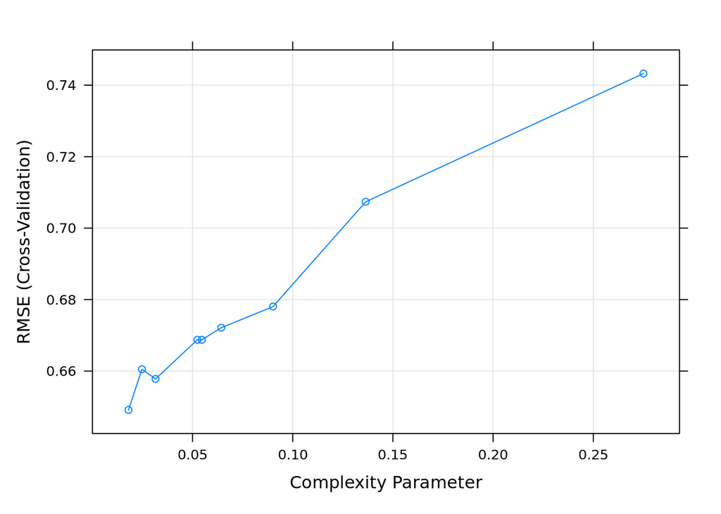

```r
plot(dtTune)
```

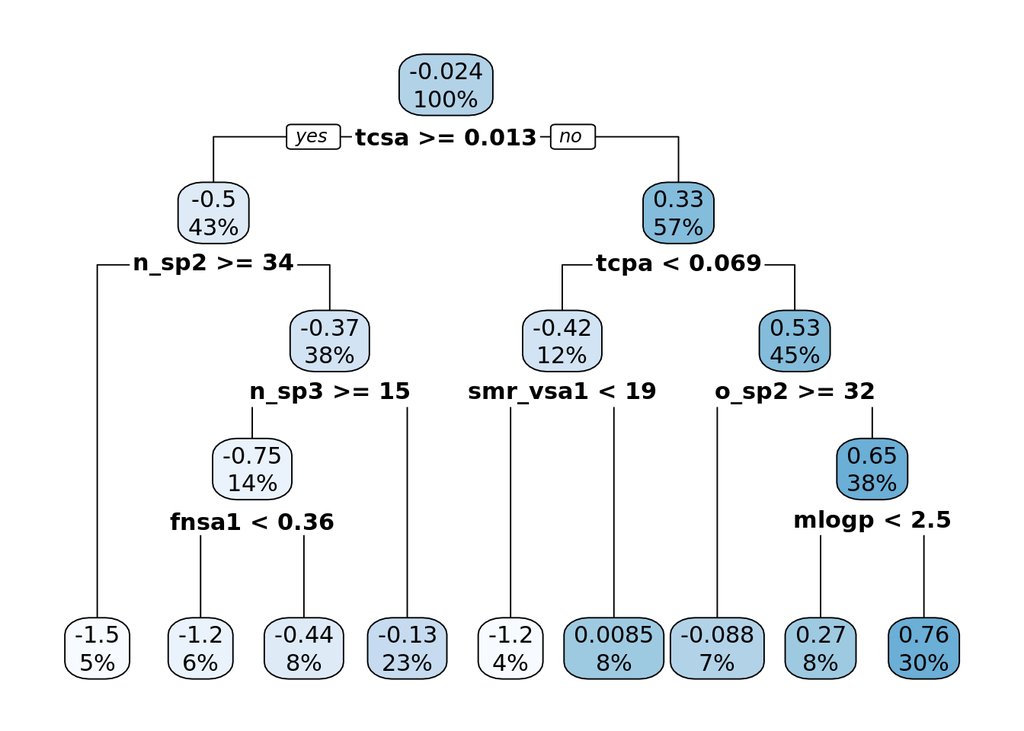

```r
# Display actual tree
library(rpart.plot)
rpart.plot(dtTune$finalModel)
```

The resulting tree looks well balanced and features a good variety of predictors. We see 9 different values which can be predicted by this model, however there are some classes with much higher numbers of training examples.

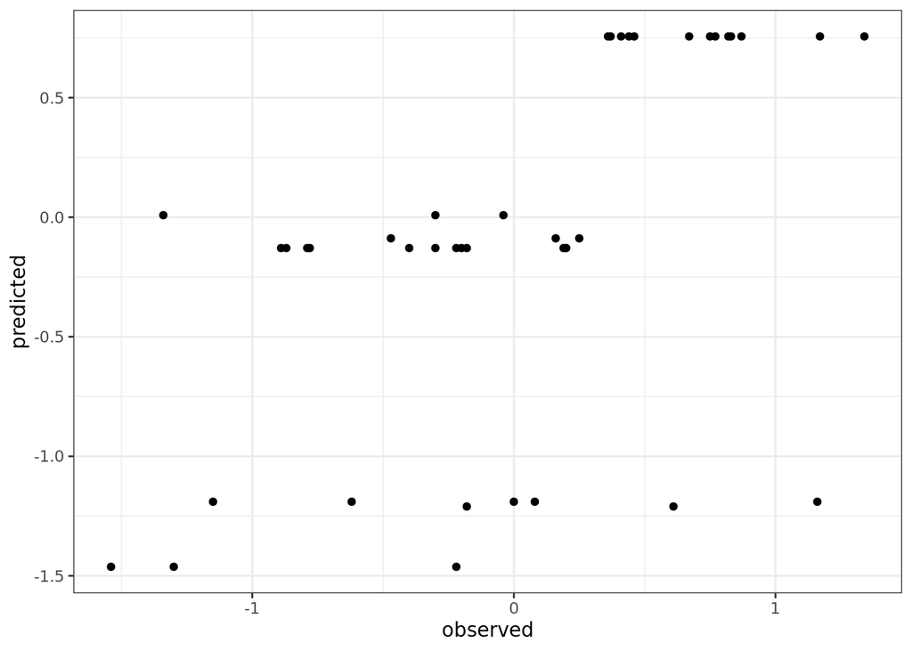

```r
# Observe the results on the test data
descrTest <- predict(transformations, descrTest)
test_pred <- predict(dtTune, descrTest)
qplot(concRatioTest, test_pred) +
  xlab("observed") +
  ylab("predicted") +
  theme_bw()
```

```r
cor(concRatioTest, test_pred)
```

```
## [1] 0.5496074
```

As you can see in the scatter plot, although we can use decision trees for regression, we still essentially perform a classification over several numerical values. In particular, we see that the values with higher numbers of training examples dominate in the test set as well. In this case, the correlation is poor and we see that a decision tree model may not be the most appropriate choice in this case.

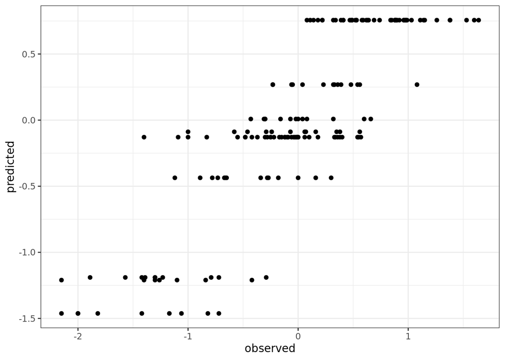

```r
# Also consider the results on the training data
train_pred <- predict(dtTune, descrTrain)
qplot(concRatioTrain, train_pred) +
  xlab("observed") +
  ylab("predicted") +
  theme_bw()
```

```r
cor(concRatioTrain, train_pred)
```

```
## [1] 0.8540512
```

### Random forest

We also test a random forest model. We expect that the random forest may perform slightly better as, by combining multiple trees, we can predict a wider range of values.

```r
# Train the random forest with 9 different mtry values.
rfTune <- train(descrTrain,
                 concRatioTrain,
                 method='rf',
                 tuneLength = 9,
                 trControl = trainControl(method="cv",
                                          number = 5,
                                          #repeats = 5,
                                          seeds=seeds
                                          )
)
rfTune
```

```
## Random Forest
##
## 168 samples
##  63 predictor
##
## No pre-processing
## Resampling: Cross-Validated (5 fold)
## Summary of sample sizes: 134, 134, 135, 134, 135
## Resampling results across tuning parameters:
##
##   mtry  RMSE       Rsquared   MAE
##    2    0.5585564  0.5594496  0.4204580
##    9    0.5398963  0.5644740  0.4041671
##   17    0.5384014  0.5601504  0.4016614
##   24    0.5394637  0.5579405  0.4012871
##   32    0.5430745  0.5499293  0.4035444
##   40    0.5392519  0.5558647  0.3983400
##   47    0.5403834  0.5531654  0.3991773
##   55    0.5471832  0.5392988  0.4025956
##   63    0.5512521  0.5322651  0.4058279
##
## RMSE was used to select the optimal model using the smallest value.
## The final value used for the model was mtry = 17.
```

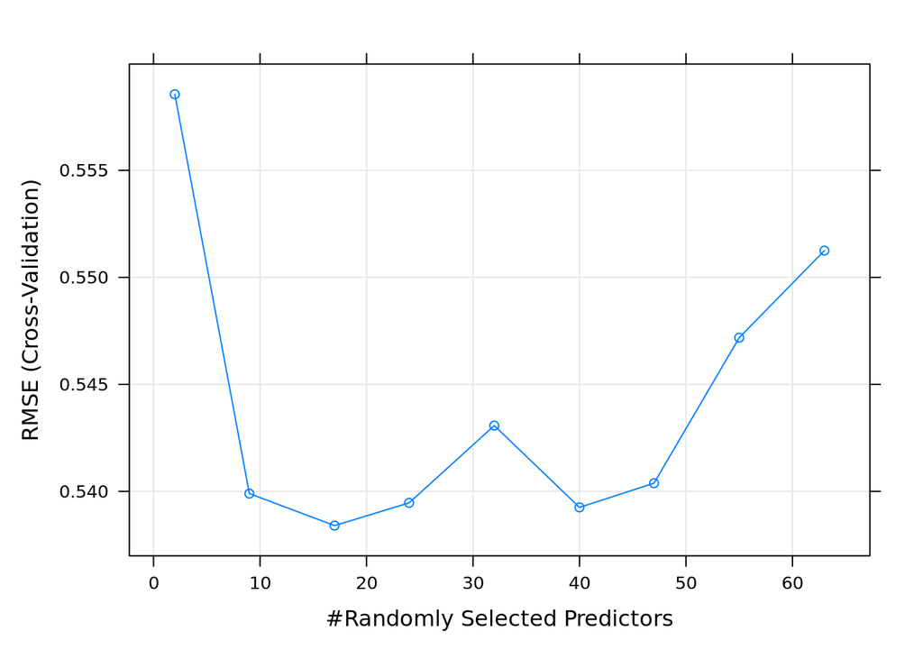

```r
plot(rfTune)
```

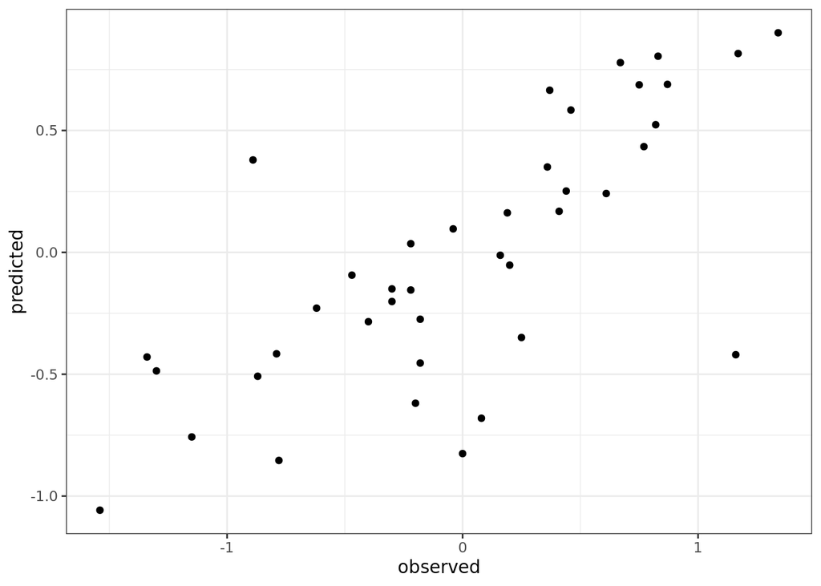

```r
# Predict outcomes on the test data
descrTest <- predict(transformations, descrTest)
test_pred <- predict(rfTune, descrTest)
qplot(concRatioTest, test_pred) +
  xlab("observed") +
  ylab("predicted") +
  theme_bw()
```

```r
cor(concRatioTest, test_pred)
```

```
## [1] 0.7345098
```

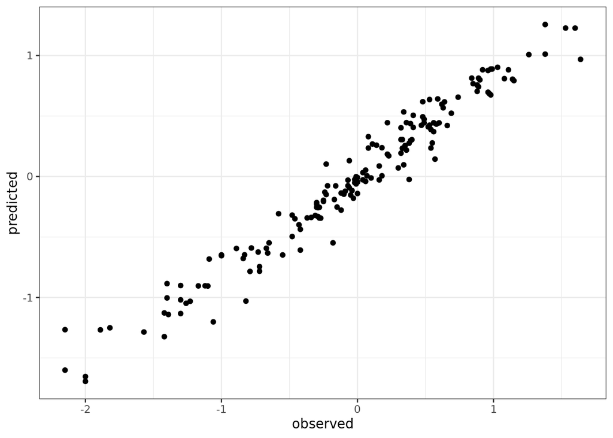

```r
# Also predict outcomes on the training data
train_pred <- predict(rfTune, descrTrain)
qplot(concRatioTrain, train_pred) +
  xlab("observed") +
  ylab("predicted") +
  theme_bw()
```

```r
cor(concRatioTrain, train_pred)
```

```
## [1] 0.9784373
```

On the training data, we see a clear relationship between observed and predicted values.

## Cell segmentation

Now, we focus on the cell segmentation data. Firstly, we train a random forest on the full training dataset.

```r
# Load data
data(segmentationData)
segClass <- segmentationData$Class
segData <- segmentationData[,4:59]

# Split into training and test
set.seed(42)
trainIndex <- createDataPartition(y=segClass, times=1, p=0.5, list=F)
segDataTrain <- segData[trainIndex,]
segDataTest <- segData[-trainIndex,]
segClassTrain <- segClass[trainIndex]
segClassTest <- segClass[-trainIndex]

# Set up cross-validation
set.seed(42)
seeds <- vector(mode = "list", length = 51)
for(i in 1:50) seeds[[i]] <- sample.int(1000, 9)
seeds[[51]] <- sample.int(1000,1)
cvCtrl <- trainControl(method = "cv",
#                       repeats = 5,
                       number = 10,
                       summaryFunction = twoClassSummary,
                       classProbs = TRUE,
                       seeds=seeds)

# Train random forest with 9 mtry values
rfTune <- train(x = segDataTrain,
                   y = segClassTrain,
                   method = 'rf',
                   tuneLength = 9,
                   preProc = c("nzv", "corr"),
                   metric = "ROC",
                   trControl = cvCtrl)

rfTune
```

```
## Random Forest
##
## 1010 samples
##   56 predictor
##    2 classes: 'PS', 'WS'
##
## Pre-processing: remove (18)
## Resampling: Cross-Validated (10 fold)
## Summary of sample sizes: 909, 909, 909, 909, 909, 909, ...
## Resampling results across tuning parameters:
##
##   mtry  ROC        Sens       Spec
##    2    0.8957692  0.8769231  0.7111111
##    8    0.8945726  0.8584615  0.7472222
##   15    0.8930342  0.8584615  0.7555556
##   22    0.8881624  0.8538462  0.7500000
##   29    0.8881624  0.8523077  0.7555556
##   35    0.8817094  0.8476923  0.7583333
##   42    0.8852778  0.8446154  0.7583333
##   49    0.8841880  0.8415385  0.7472222
##   56    0.8830342  0.8492308  0.7555556
##
## ROC was used to select the optimal model using the largest value.
## The final value used for the model was mtry = 2.
```

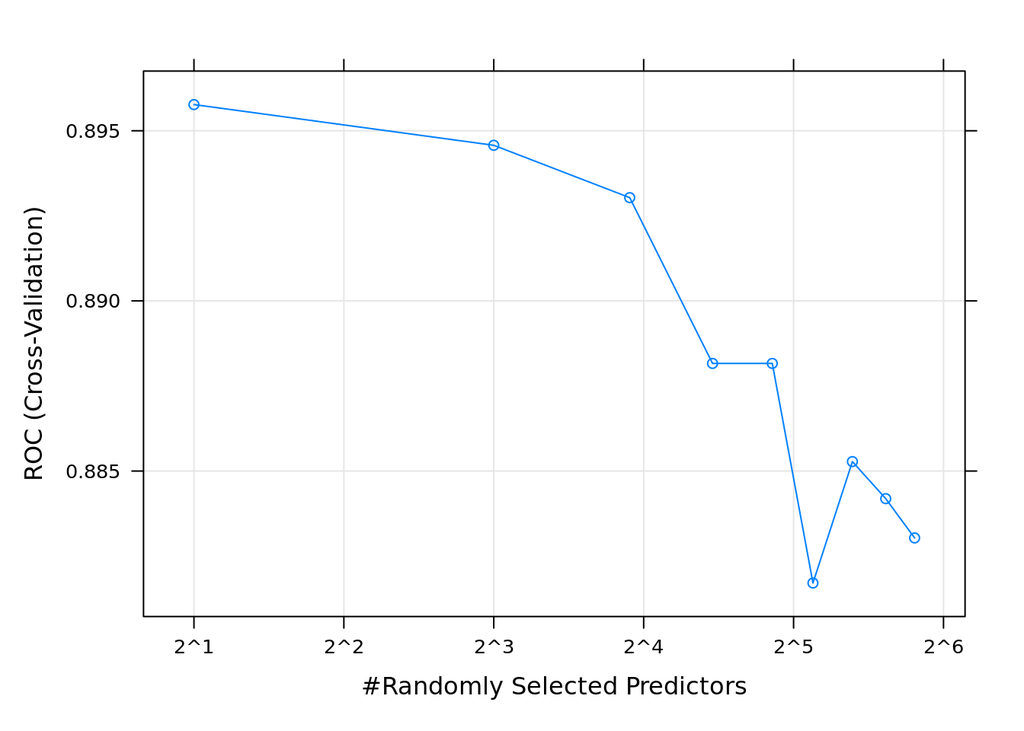

```r
plot(rfTune, metric = "ROC", scales = list(x = list(log = 2)))
```

```r
# Predict performance on test data
rfPred <- predict(rfTune, segDataTest)
confusionMatrix(rfPred, segClassTest)
```

```
## Confusion Matrix and Statistics
##
##           Reference
## Prediction  PS  WS
##         PS 576 106
##         WS  74 253
##
##                Accuracy : 0.8216
##                  95% CI : (0.7966, 0.8448)
##     No Information Rate : 0.6442
##     P-Value [Acc > NIR] : < 2e-16
##
##                   Kappa : 0.6029
##
##  Mcnemar's Test P-Value : 0.02085
##
##             Sensitivity : 0.8862
##             Specificity : 0.7047
##          Pos Pred Value : 0.8446
##          Neg Pred Value : 0.7737
##              Prevalence : 0.6442
##          Detection Rate : 0.5709
##    Detection Prevalence : 0.6759
##       Balanced Accuracy : 0.7954
##
##        'Positive' Class : PS
##
```

```r
# Predict performance on test data using class probabilities
rfProbs <- predict(rfTune, segDataTest, type="prob")
head(rfProbs)
```

```
##       PS    WS
## 1  0.912 0.088
## 5  0.888 0.112
## 8  0.946 0.054
## 9  0.646 0.354
## 10 0.866 0.134
## 12 0.766 0.234
```

```r
library(pROC)
# Compute ROC
rfROC <- roc(segClassTest, rfProbs[,"PS"])
auc(rfROC)
```

```
## Area under the curve: 0.897
```

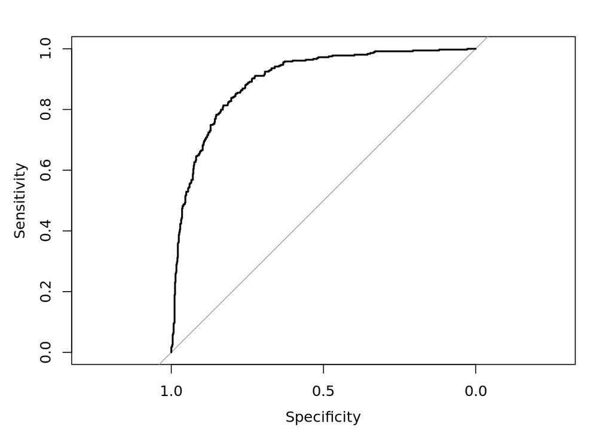

```r
plot(rfROC, type = "S")
```

```r
auc(rfROC)
```

```
## Area under the curve: 0.897
```

### Subsampling Cell Segmentation data - Random Forest

We now want to see what the effect is of subsampling the larger class (PS) to the same size as the smaller class. We perform this exactly as we did for the kNN example. First we load the data exactly as before:

```r
# Load the data as before
data(segmentationData)
str(segmentationData)
```

```
## 'data.frame':    2019 obs. of  61 variables:
##  $ Cell                   : int  207827637 207932307 207932463 207932470 207932455 207827656 207827659 207827661 207932479 207932480 ...
##  $ Case                   : Factor w/ 2 levels "Test","Train": 1 2 2 2 1 1 1 1 1 1 ...
##  $ Class                  : Factor w/ 2 levels "PS","WS": 1 1 2 1 1 2 2 1 2 2 ...
##  $ AngleCh1               : num  143.25 133.75 106.65 69.15 2.89 ...
##  $ AreaCh1                : int  185 819 431 298 285 172 177 251 495 384 ...
##  $ AvgIntenCh1            : num  15.7 31.9 28 19.5 24.3 ...
##  $ AvgIntenCh2            : num  4.95 206.88 116.32 102.29 112.42 ...
##  $ AvgIntenCh3            : num  9.55 69.92 63.94 28.22 20.47 ...
##  $ AvgIntenCh4            : num  2.21 164.15 106.7 31.03 40.58 ...
##  $ ConvexHullAreaRatioCh1 : num  1.12 1.26 1.05 1.2 1.11 ...
##  $ ConvexHullPerimRatioCh1: num  0.92 0.797 0.935 0.866 0.957 ...
##  $ DiffIntenDensityCh1    : num  29.5 31.9 32.5 26.7 31.6 ...
##  $ DiffIntenDensityCh3    : num  13.8 43.1 36 22.9 21.7 ...
##  $ DiffIntenDensityCh4    : num  6.83 79.31 51.36 26.39 25.03 ...
```

[output cut: 47 more lines]

```r
segClass <- segmentationData$Class
segData <- segmentationData[,4:59]
set.seed(42)
trainIndex <- createDataPartition(y=segClass, times=1, p=0.5, list=F)
segDataTrain <- segData[trainIndex,]
segDataTest <- segData[-trainIndex,]
segClassTrain <- segClass[trainIndex]
segClassTest <- segClass[-trainIndex]
summary(segClassTrain)
```

```
##  PS  WS
## 650 360
```

```r
summary(segClassTest)
```

```
##  PS  WS
## 650 359
```

We then need to down-sample the larger class:

```r
set.seed(42)
segSub <- downSample(segDataTrain, segClassTrain, list = FALSE, yname = "Class")
segDataTrainSub <- segSub[,1:(ncol(segSub)-1)]
segClassTrainSub <- segSub$Class
```

Now we train the random forest and observe the resulting performance.

```r
# Set up cross-validation
set.seed(42)
seeds <- vector(mode = "list", length = 51)
for(i in 1:50) seeds[[i]] <- sample.int(1000, 9)
seeds[[51]] <- sample.int(1000,1)
cvCtrl <- trainControl(method = "cv",
#                       repeats = 5,
                       number = 5,
                       summaryFunction = twoClassSummary,
                       classProbs = TRUE,
                       seeds=seeds)

# Train random forest
rfTune <- train(x = segDataTrainSub,
                   y = segClassTrainSub,
                   method = 'rf',
                   tuneLength = 9,
                   preProc = c("nzv","corr"),
                   metric = "ROC",
                   trControl = cvCtrl)

rfTune
```

```
## Random Forest
##
## 720 samples
##  56 predictor
##   2 classes: 'PS', 'WS'
##
## Pre-processing: remove (17)
## Resampling: Cross-Validated (5 fold)
## Summary of sample sizes: 576, 576, 576, 576, 576
## Resampling results across tuning parameters:
##
##   mtry  ROC        Sens       Spec
##    2    0.8843171  0.7527778  0.8277778
##    8    0.8862847  0.7444444  0.8416667
##   15    0.8804977  0.7500000  0.8444444
##   22    0.8786073  0.7500000  0.8611111
##   29    0.8760995  0.7444444  0.8555556
##   35    0.8746142  0.7333333  0.8500000
##   42    0.8734761  0.7388889  0.8444444
##   49    0.8712577  0.7388889  0.8555556
##   56    0.8724151  0.7361111  0.8500000
##
## ROC was used to select the optimal model using the largest value.
## The final value used for the model was mtry = 8.
```

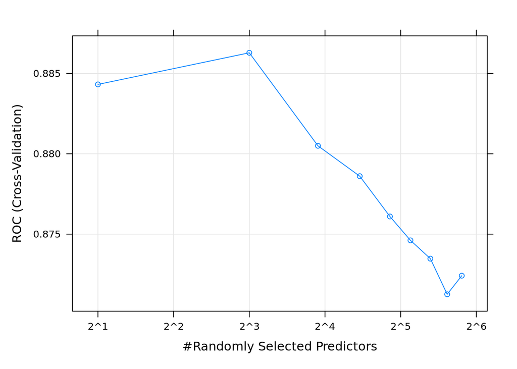

```r
plot(rfTune, metric = "ROC", scales = list(x = list(log =2)))
```

We then test the model on our test data, firstly just predicting classes:

```r
# Predict outcome on test data
rfPred <- predict(rfTune, segDataTest)
confusionMatrix(rfPred, segClassTest)
```

```
## Confusion Matrix and Statistics
##
##           Reference
## Prediction  PS  WS
##         PS 510  51
##         WS 140 308
##
##                Accuracy : 0.8107
##                  95% CI : (0.7851, 0.8344)
##     No Information Rate : 0.6442
##     P-Value [Acc > NIR] : < 2.2e-16
##
##                   Kappa : 0.6088
##
##  Mcnemar's Test P-Value : 1.922e-10
##
##             Sensitivity : 0.7846
##             Specificity : 0.8579
##          Pos Pred Value : 0.9091
##          Neg Pred Value : 0.6875
##              Prevalence : 0.6442
##          Detection Rate : 0.5055
##    Detection Prevalence : 0.5560
##       Balanced Accuracy : 0.8213
##
##        'Positive' Class : PS
##
```

Now, we predict class probabilities so we can build a ROC curve:

```r
# Predict outcome on test data using class probabilities
rfProbs <- predict(rfTune, segDataTest, type="prob")
head(rfProbs)
```

```
##       PS    WS
## 1  0.894 0.106
## 5  0.882 0.118
## 8  0.940 0.060
## 9  0.644 0.356
## 10 0.868 0.132
## 12 0.676 0.324
```

```r
rfROC <- roc(segClassTest, rfProbs[,"PS"])
auc(rfROC)
```

```
## Area under the curve: 0.8968
```

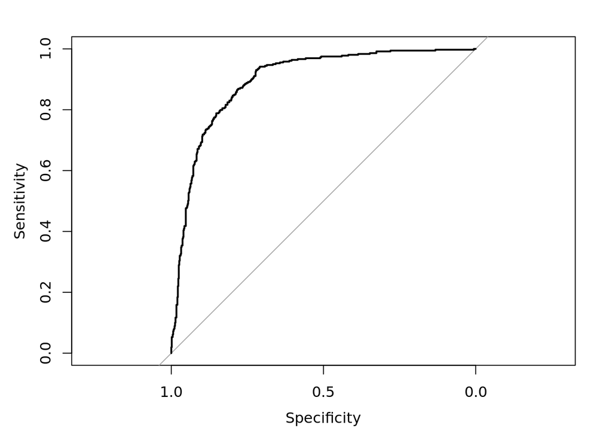

```r
plot(rfROC, type = "S")
```

```r
auc(rfROC)
```

```
## Area under the curve: 0.8968
```

We can then do exactly the same on the subsampled training data:

```r
rfPred <- predict(rfTune, segDataTrainSub)
confusionMatrix(rfPred, segClassTrainSub)
```

```
## Confusion Matrix and Statistics
##
##           Reference
## Prediction  PS  WS
##         PS 360   0
##         WS   0 360
##
##                Accuracy : 1
##                  95% CI : (0.9949, 1)
##     No Information Rate : 0.5
##     P-Value [Acc > NIR] : < 2.2e-16
##
##                   Kappa : 1
##
##  Mcnemar's Test P-Value : NA
##
##             Sensitivity : 1.0
##             Specificity : 1.0
##          Pos Pred Value : 1.0
##          Neg Pred Value : 1.0
##              Prevalence : 0.5
##          Detection Rate : 0.5
##    Detection Prevalence : 0.5
##       Balanced Accuracy : 1.0
##
##        'Positive' Class : PS
##
```

```r
rfProbs <- predict(rfTune, segDataTrainSub, type="prob")
head(rfProbs)
```

```
##      PS    WS
## 1 0.870 0.130
## 2 0.988 0.012
## 3 0.994 0.006
## 4 0.646 0.354
## 5 0.720 0.280
## 6 0.966 0.034
```

```r
rfROC <- roc(segClassTrainSub, rfProbs[,"PS"])
auc(rfROC)
```

```
## Area under the curve: 1
```

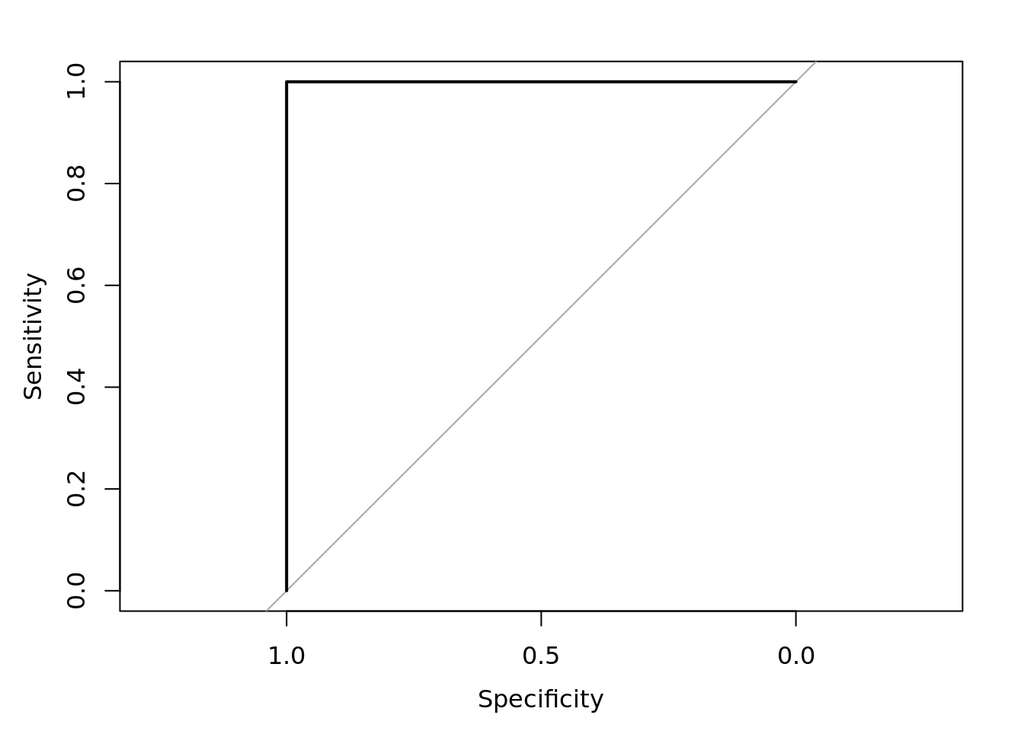

```r
plot(rfROC, type = "S")
```

```r
auc(rfROC)
```

```
## Area under the curve: 1
```

### Subsampling Cell Segmentation data - Decision tree

Exactly as for random forests, we train our decision tree:

```r
# Train decision tree
dtreeTune <- train(x = segDataTrainSub,
                   y = segClassTrainSub,
                   method = 'rpart',
                   tuneLength = 9,
                   preProc = c("nzv","corr"),
                   metric = "ROC",
                   trControl = cvCtrl)

dtreeTune
```

```
## CART
##
## 720 samples
##  56 predictor
##   2 classes: 'PS', 'WS'
##
## Pre-processing: remove (17)
## Resampling: Cross-Validated (5 fold)
## Summary of sample sizes: 576, 576, 576, 576, 576
## Resampling results across tuning parameters:
##
##   cp          ROC        Sens       Spec
##   0.00000000  0.8305748  0.7277778  0.7527778
##   0.07222222  0.7833333  0.6416667  0.9250000
##   0.14444444  0.7833333  0.6416667  0.9250000
##   0.21666667  0.7833333  0.6416667  0.9250000
##   0.28888889  0.7833333  0.6416667  0.9250000
##   0.36111111  0.7833333  0.6416667  0.9250000
##   0.43333333  0.7833333  0.6416667  0.9250000
##   0.50555556  0.7833333  0.6416667  0.9250000
##   0.57777778  0.6597222  0.7750000  0.5444444
##
## ROC was used to select the optimal model using the largest value.
## The final value used for the model was cp = 0.
```

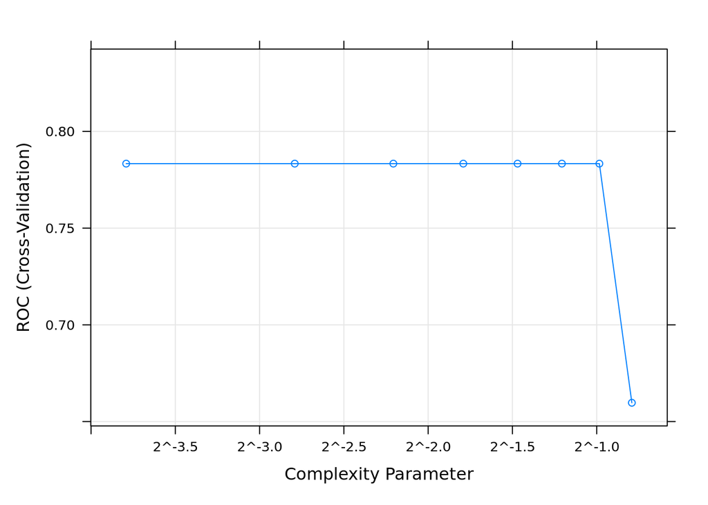

```r
plot(dtreeTune, metric = "ROC", scales = list(x = list(log =2)))
```

We then test it on the test data, using classes then class probabilities:

```r
# Predict outcome on test data
dtreePred <- predict(dtreeTune, segDataTest)
confusionMatrix(dtreePred, segClassTest)
```

```
## Confusion Matrix and Statistics
##
##           Reference
## Prediction  PS  WS
##         PS 518  79
##         WS 132 280
##
##                Accuracy : 0.7909
##                  95% CI : (0.7645, 0.8156)
##     No Information Rate : 0.6442
##     P-Value [Acc > NIR] : < 2.2e-16
##
##                   Kappa : 0.5584
##
##  Mcnemar's Test P-Value : 0.0003438
##
##             Sensitivity : 0.7969
##             Specificity : 0.7799
##          Pos Pred Value : 0.8677
##          Neg Pred Value : 0.6796
##              Prevalence : 0.6442
##          Detection Rate : 0.5134
##    Detection Prevalence : 0.5917
##       Balanced Accuracy : 0.7884
##
##        'Positive' Class : PS
##
```

```r
# Predict outcome on test data using class probabilities
dtreeProbs <- predict(dtreeTune, segDataTest, type="prob")
head(dtreeProbs)
```

```
##           PS         WS
## 1  0.9227642 0.07723577
## 5  0.9227642 0.07723577
## 8  0.9227642 0.07723577
## 9  0.8928571 0.10714286
## 10 0.9227642 0.07723577
## 12 0.9227642 0.07723577
```

```r
dtreeROC <- roc(segClassTest, dtreeProbs[,"PS"])
auc(dtreeROC)
```

```
## Area under the curve: 0.8299
```

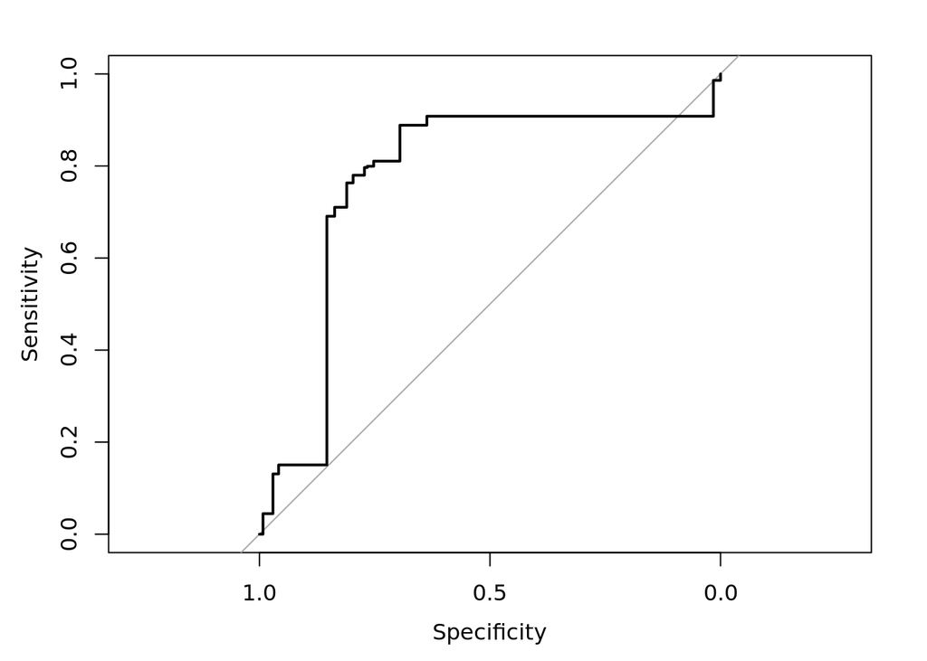

```r
plot(dtreeROC, type = "S")
```

```r
auc(dtreeROC)
```

```
## Area under the curve: 0.8299
```

Again, we do the same for the subsampled training data:

```r
dtreePred <- predict(dtreeTune, segDataTrainSub)
confusionMatrix(dtreePred, segClassTrainSub)
```

```
## Confusion Matrix and Statistics
##
##           Reference
## Prediction  PS  WS
##         PS 308  37
##         WS  52 323
##
##                Accuracy : 0.8764
##                  95% CI : (0.8501, 0.8995)
##     No Information Rate : 0.5
##     P-Value [Acc > NIR] : <2e-16
##
##                   Kappa : 0.7528
##
##  Mcnemar's Test P-Value : 0.1378
##
##             Sensitivity : 0.8556
##             Specificity : 0.8972
##          Pos Pred Value : 0.8928
##          Neg Pred Value : 0.8613
##              Prevalence : 0.5000
##          Detection Rate : 0.4278
##    Detection Prevalence : 0.4792
##       Balanced Accuracy : 0.8764
##
##        'Positive' Class : PS
##
```

```r
dtreeProbs <- predict(dtreeTune, segDataTrainSub, type="prob")
head(dtreeProbs)
```

```
##          PS         WS
## 1 0.9227642 0.07723577
## 2 0.9227642 0.07723577
## 3 0.9227642 0.07723577
## 4 0.1264822 0.87351779
## 5 0.1162791 0.88372093
## 6 0.9227642 0.07723577
```

```r
dtreeROC <- roc(segClassTrainSub, dtreeProbs[,"PS"])
auc(dtreeROC)
```

```
## Area under the curve: 0.8984
```

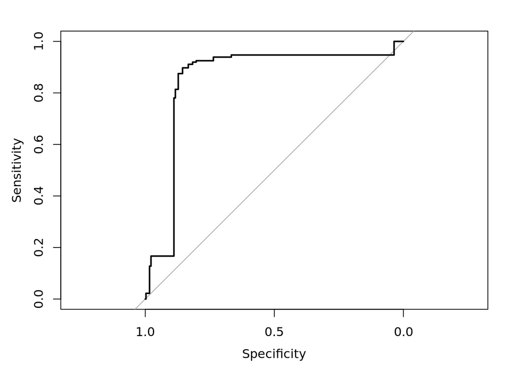

```r
plot(dtreeROC, type = "S")
```

```r
auc(dtreeROC)
```

```
## Area under the curve: 0.8984
```